# Lab 1

Becca Reynolds

1/9/2020

Attach packages

```r
library(tidyverse)
library(here)
library(janitor)
library(kableExtra)
```

Read in NOAA Fisheries data Use here() if .csv is not in your working directory. You can also use “data/noaa_fisheries.csv” but it’s safer to use here() because it can ALSO pull from upstream.

```r
us_landings <- read_csv(here("data","noaa_fisheries.csv"))
```

Tidy data

```r
landings_tidy <- us_landings %>%
  janitor::clean_names() %>%
  mutate(state = str_to_lower(state),
         afs_name = str_to_lower(afs_name)) %>%
  mutate(dollars_num = parse_number(dollars_usd))
```

#^^dollars_usd is going to be read as a character because you have at least one non-numeric thing ($) in the observation. We want to get rid of the ($) and store as numeric There are many different functions in the readr package to parse things, like ?parse_number Use this this with mutate on dollars_usd to drop non-numeric characters

Get info for salmon:

```r
salmon_landings <- landings_tidy %>%
  mutate(afs_clean = str_remove(afs_name, pattern = "aggregate")) %>%
  filter(str_detect(afs_clean, pattern = "salmon")) %>%
  separate(afs_clean, into = c("group", "species"), sep = ",")
```

Find some grouped summary data:

Find annual total of US landings and dollar value by summing across all states for each type of salmon using group_by() and summarize()

SO group by year and species…

```r
salmon_summary <- salmon_landings %>%
  group_by(year, species) %>%
  summarize(
    tot_landings = sum(landings_pounds),
    tot_value = sum(dollars_num)
  )
```

Make a graph to visualize this

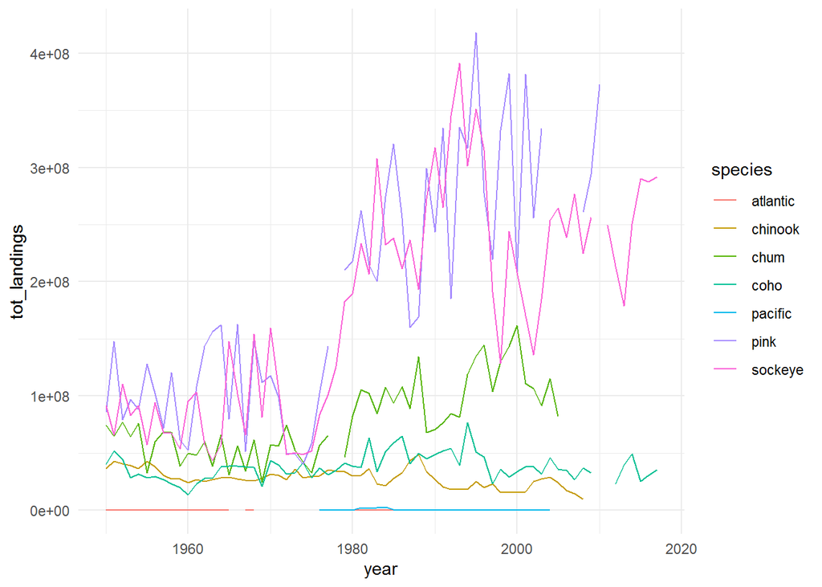

```r
salmon_landings_graph <- ggplot(data = salmon_summary,
                                aes(x = year, y = tot_landings)) +
  geom_line(aes(color = species)) +
  theme_minimal()

salmon_landings_graph
```

You could also group by species like this: ggplot(data = salmon_summary, aes(x = year, y = tot_landings, group = species)) + geom_line()

But it won’t assign colors to each species like it does using the code in the code chunk above.

Export graph

```r
ggsave(plot = salmon_landings_graph,
       here("figures", "us_salmon_br.png"),
       height =5,
       width = 8)
```

save the graph to the foler “figures” in this repo. here let’s you do this. you can specify dpi, size, …etc.

Make a table

```r
salmon_first_5 <- salmon_summary %>%
  head(5)
```

```r
kable(salmon_first_5) %>%
  kable_styling(bootstrap_options = "striped",
                full_width = FALSE)
```

| year | species | tot_landings | tot_value |
| --- | --- | --- | --- |
| 1950 | atlantic | 800 | 362 |
| 1950 | chinook | 36559160 | 8328433 |
| 1950 | chum | 74610432 | 5920158 |
| 1950 | coho | 40224632 | 7151008 |
| 1950 | pink | 85773432 | 6773180 |